# Optimization of 3’-end trimming positions for merging paired ends with dada2

Ignasi

22/11/2019

The denoising step can be done with paired ends or with the already merged reads. I was surprised by the low proportion of successfully merged pairs by dada2 in some samples, in comparison to the number of merged reads available from the sequencing services. I suspected the problem was in the parameters that control the trimming of reads at their 3’ ends before merging, and I tested several combinations of values between the two ends: 0, 200, 225, 250, 275, and 295, where ‘0’ means ‘no trimming’. Table `FromClean/summaryStats.txt` holds the summary statistics from all 36 runs.

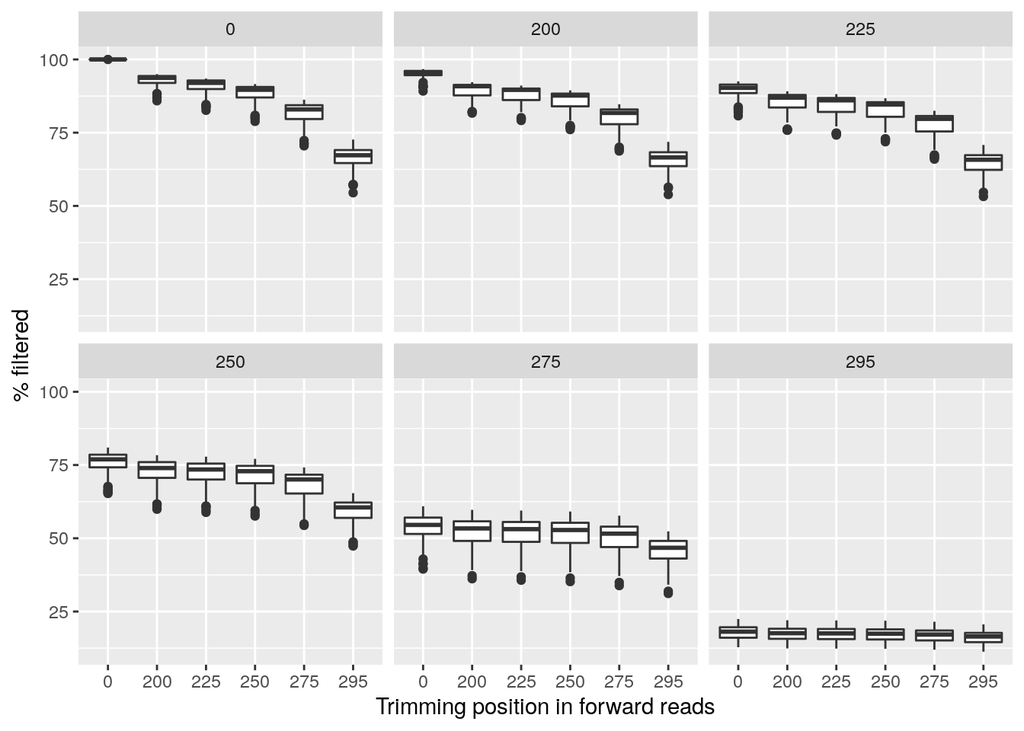

```r
library(ggplot2)
library(tidyr)
merging <- read.table('FromClean/summaryStats.txt', skip=1,
                      col.names=c('Sample','input','filtered','filtered.p','denoised','merged','merged.p','trusted','trusted.p','trunc.f','trunc.r'))
ggplot(merging, mapping=aes(x=as.factor(trunc.f), y=filtered.p)) + geom_boxplot() +
  facet_wrap(~trunc.r) + xlab('Trimming position in forward reads') + ylab('% filtered')
```

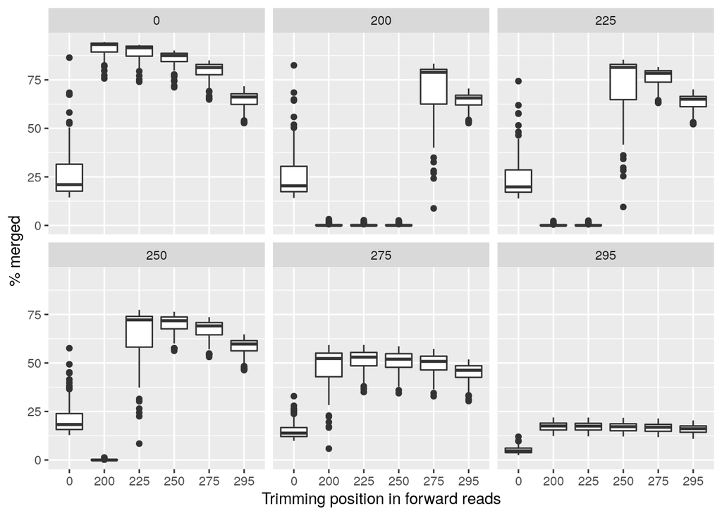

```r
ggplot(merging, mapping=aes(x=as.factor(trunc.f), y=merged.p)) + geom_boxplot() +
  facet_wrap(~trunc.r) + xlab('Trimming position in forward reads') + ylab('% merged')
```

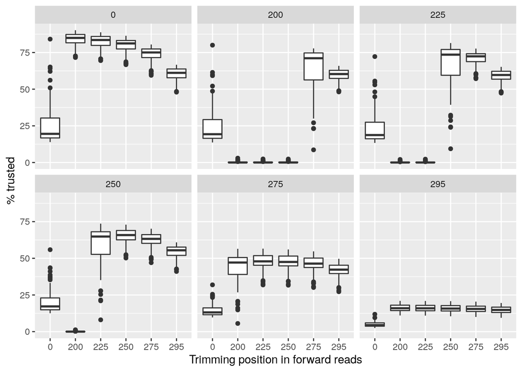

```r
ggplot(merging, mapping=aes(x=as.factor(trunc.f), y=trusted.p)) + geom_boxplot() +
  facet_wrap(~trunc.r) + xlab('Trimming position in forward reads') + ylab('% trusted')
```

I see that among the three steps executed with dada2 (filtering, merging, and removing chimeras), merging has a dramatic effect. First, there is a threshold effect, as expected if the two reads are too short to overlap at least 20 nucleotides (aparently required by dada2). Then, there is an evident limit to the performance of the merging step by the filtering step. The longer the trimming position, the fewer reads are left. This is because dada2 discards reads shorter than the trimming position.

Discarding short reads before attempting to merge them seems motivated by the fear of generating spurious mergings, and also by computational efficiency. However, these being reads that had already been trimmed before, during quality control, it is very unfortunate to deny the chance of merging high-quality, slightly shorter reads. Note that the overall merging performance when reverse reads are trimmed at position 225 decreases between forward trimming positions 250 and 275. The only reason some shorter pairs that merged in the first place don’t merge in the second is that they were removed. I would say that the underlying reason for this unnecessary loss of efficiency is the application of the *same* trimming positions to all read pairs. Read pairs vary in quality and origin. Cutting them all with the same *cookie-cutter* does not make the most efficient use of data.

According to this, I expected that neither trimming nor filtering the data (trimming position ‘0’ in both reads) would produce the best results. But it does not. Actually, leaving forward reads untrimmed has a very negative effect in all cases. The most efficient merging happens when forward reads are most heavily trimmed (to 200 bases) and reverse reads are left untrimmed. I don’t know why; I wonder if it’s an artifact of dada2’s algorithm.

In the plot below, see how some samples reach their maximum proportion of merged reads when reads are `225 + 250 = 475` nucleotides long, which is enough to reach an overlap of 20 for original fragments of up to 455 nucleotides, including one of the most frequent gene lengths of 440, but excluding the other one, of 465. Other samples, reach their maximum for reads of `225 + 275 = 500`, which are long enough to reach the minimum overlap for fragments 465 nucleotides long. But then, the samples dominated by the shorter genes lost part of the reads reporting their abundance.

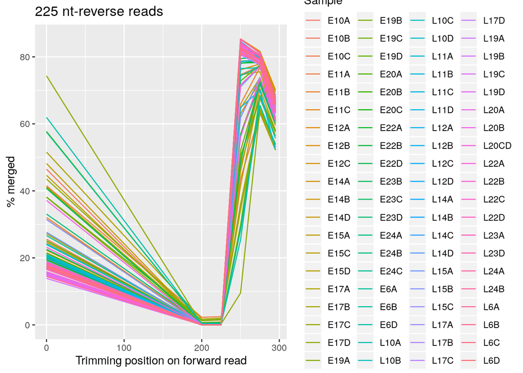

```r
ggplot(merging[merging$trunc.r==225,], mapping=aes(x=trunc.f, y=merged.p, color=Sample)) + geom_line() +
  xlab('Trimming position on forward read') + ggtitle('225 nt-reverse reads') + ylab('% merged')
```

# Conclusion

It is not a good idea to require all reads to be the same length before merging, as if all target fragments were the same length. Maybe a better way to show it would have been to unpack the merging results and look at their length distributions.

The sequencing center used [FLASH](https://dx.doi.org/10.1093/bioinformatics/btr507) to merge the paired ends, which assembles each pair independently, without assuming a common total length. Therefore, I abandon the idea of using the clean, unmerged pairs to run my own merging. Instead from now on I will use the reads merged by the sequencing service. They achieved merging rates above 79% in all samples (not shown).